# **Introduction to R**

Modifications:** Giorgi Nikolaishvili **Original Authors:** Kyle Raze, Youssef Ait Benasser, & Saurabh Gupta EC 320: Introduction to Econometrics University of Oregon

Spring 2022

## Labs vs. Lectures

**Lectures:** learning new econometric concepts, math, research design, etc.

**Labs:** gathering tools to apply the above concepts to real data.

## A Little Bit About Me

Full name: Giorgi Nikolaishvili – you can either refer to me as Gio (“G” pronounced as in “great” or “Google”), or George.

Tbilisi, Georgia -> Washington, D.C. -> Tbilisi, Georgia -> Kyiv, Ukraine -> Boston, MA -> Eugene, OR.

Like Emmett, I’m also a 3rd-year Economics PhD Candidate.

Research areas: macroeconomics & time series econometrics.

I study how the banking and financial sectors evolve over time using statistical modeling.

I use R to work with data, and Julia to construct statistical algorithms.

This quarter I started learning C and C++ from scratch – so we’re in the same boat in terms of learning new languages!

## What is R?

- R is a programming language and environment for statistical computing and graphics.
- R provides a wide variety of statistical and graphical techniques, and is highly extensible.
- R is *not* a general-purpose programming language.
- R is free and open-source.
- R is used mainly by statisticians, both in the private sector (data scientists) and academia.
- R is used extensively within the economics profession due to its ease-of-use, flexibility, and reproducibility.

## What is RStudio?

RStudio is an IDE (Integrated Development Environment) for R.

R is the language and RStudio helps us interact with R.

Basically, if R is the engine, chassis, wheels, etc. of a car, then RStudio is its dashboard containing various buttons and monitors that, while “unneccessary”, can make the driving experience easier and more effective.

You can still program in R without RStudio, but RStudio is useless without R.

## Installation

Having R and RStudio on your laptop will allow you to work on problem sets and explore the functionality of R outside the lab.

It is important that you **install R before you install R Studio.**

### Install R

In your web browser, go to r-project.org and then click [download R](https://cran.r-project.org/mirrors.html). At this point, you’ll be directed to a page with a list of institutions that host the Comprehensive R Archive Network (CRAN). The idea is to pick an institution near you. Scroll down to USA and click the link for either [UC Berkeley](https://cran.cnr.berkeley.edu) or [OSU](https://ftp.osuosl.org/pub/cran/).

**Windows Instructions:** If you have a Windows machine, click `Download R for Windows` then `install R for the first time` then `Download R 4.1.3 for Windows`. To complete installation, run the `.exe` file you downloaded.

**Mac Instructions:** If you have a Mac, click `Download R for (Mac) OS X` then `R-4.1.3.pkg` under “latest release.” To complete installation, run the `.pkg` file you downloaded.

**Linux Instructions:** If you run a Linux distro, note that installation instructions vary by distro. That said, you probably know what you’re doing.

### Install RStudio

- In your web browser, go to rstudio.com/products/rstudio/, scroll down to R Studio Desktop, and then click [Download RStudio Desktop](https://rstudio.com/products/rstudio/download/) under “Open Source Edition.” Scroll down to “All Installers” and click the link that corresponds with your operating system.
- To complete installation, run the installer you downloaded.

## R Basics

In this section we learn the absolute basic elements of R.

### R as a Calculator

Addition:

```r
2+2
```

```
## [1] 4
```

Subtraction:

```r
2-2
```

```
## [1] 0
```

Multiplication:

```r
2*2
```

```
## [1] 4
```

Division:

```r
2/2
```

```
## [1] 1
```

Exponentiation:

```r
2^2
```

```
## [1] 4
```

(Natural) logarithms:

```r
log(2)
```

```
## [1] 0.6931472
```

### Variables

It is often useful to store information into objects/variables.

```r
a <- 2
b <- 3
c <- a * b + a^b - log(b)/a
```

The operator `<-` is referred to as the assignment operator.

Let’s print variable `c` to see what it looks like:

```r
print(c)
```

```
## [1] 13.45069
```

There exist many different classes of objects. Let’s see what class object `c` belongs to:

```r
class(c)
```

```
## [1] "numeric"
```

We can also create objects of class “character” (essentially text):

```r
sometext <- "Hello World"
class(sometext)
```

```
## [1] "character"
```

There are many other object classes – we will run into new ones throughout the quarter. A nice reference for the universe of standard object classes (data types) can be found [here](https://www.tutorialspoint.com/r/r_data_types.htm).

### Functions

Functions take objects as inputs, and generate outputs that can be stored as new objects.

We’ve already run into one function – `class`.

The `class` function takes any object as an input, and generates its class as an output.

Another great example of a function is `c`, which takes multiple inputs (of comparable dimensions) and combines them into a single vector:

```r
testvec <- c(a,b,c)
print(testvec)
```

```
## [1]  2.00000  3.00000 13.45069
```

We may now access the values of objects `a`, `b`, and `c` as elements of `testvec`:

```r
testvec[2]
```

```
## [1] 3
```

We may also create out own functions:

```r
add <- function(arg1, arg2){
  arg1 + arg2
}
add(1,2)
```

```
## [1] 3
```

### Packages

R functions come in packages.

Each package contains a library of specialized functions.

Think of a package as a toolbox, and its functions as the actual tools – a package simply keeps functions neatly grouped, organized, and labeled.

When you open a fresh R session in RStudio, a number of packages come pre-loaded. These include packages with common math and statistics functions and are known collectively as “base R.”

Base R is wonderful, but non-default packages offer a great deal of flexibility and functionality.

**Install a package:** `install.packages("package.name.here")`

- Replace `package.name.here` with the name of the package you want to install.
- Make sure the name of the package is in quotes.
- You only have to install a package once.

**Load a package:** `library(package.name.here)`

- To use functions from a non-base package, you need to load the package at the beginning of each new R session.
- Quotes around the package name are no longer needed.

#### **`pacman`**

We will often need to load several packages in a single session. One way to do this is to execute `library(package.1)`, then `library(package.2)`, then `library(package.3)`, and so forth. A less cumbersome way to load multiple packages is to use the `p_load` function from the `pacman` package.

- Use the instructions above to **install `pacman`**.
- Load the `pacman` package with `library(pacman)`.
- When you want to load additional packages, you can then execute `p_load(package.1, package.2, package.3)`.
- **Added bonus:** `p_load` first checks to see if the packages are installed. If they aren’t, then it will install them for you.

### R Scripts vs. The Console

To produce reproducible R code, it is best to use scripts. Open a new R script file with the `.R` extension by clicking `File` then `New File` then `R Script`. We will write our first script to generate a histogram and scatter plot using `ggplot2`.

### `ggplot2`

Start by writing code to install and load `ggplot2`.

```r
library(pacman)
p_load(ggplot2)
```

- To execute *one line of your script*, click the line you want to run and then click `Run` at the upper-right corner of your R script. A quicker alternative is to click the line you want to run and then use the keyboard shortcut `Ctrl` `Enter`.
- To execute *the entire script*, click `Source` at the upper-right corner of your R script or use the keyboard shortcut `Ctrl` `Alt` `R`.

**Aside:** It is useful to leave comments in your code to explain to your future self what your code is doing and why. You can leave a comment by typing a hash `#`:

```r
# This is a comment. R will ignore it.
```

Check out the example dataset `midwest` from `ggplot2`. You can view the first few rows of the dataset with variable names by using the `head` function.

```r
head(midwest)
```

```
## # A tibble: 6 x 28
##     PID county   state  area poptotal popdensity popwhite popblack popamerindian
##   <int> <chr>    <chr> <dbl>    <int>      <dbl>    <int>    <int>         <int>
## 1   561 ADAMS    IL    0.052    66090      1271.    63917     1702            98
## 2   562 ALEXAND~ IL    0.014    10626       759      7054     3496            19
## 3   563 BOND     IL    0.022    14991       681.    14477      429            35
## 4   564 BOONE    IL    0.017    30806      1812.    29344      127            46
## 5   565 BROWN    IL    0.018     5836       324.     5264      547            14
## 6   566 BUREAU   IL    0.05     35688       714.    35157       50            65
## # ... with 19 more variables: popasian <int>, popother <int>, percwhite <dbl>,
## #   percblack <dbl>, percamerindan <dbl>, percasian <dbl>, percother <dbl>,
## #   popadults <int>, perchsd <dbl>, percollege <dbl>, percprof <dbl>,
## #   poppovertyknown <int>, percpovertyknown <dbl>, percbelowpoverty <dbl>,
## #   percchildbelowpovert <dbl>, percadultpoverty <dbl>,
## #   percelderlypoverty <dbl>, inmetro <int>, category <chr>
```

Next, make a histogram of county poverty rates (measured by the variable `percbelowpoverty`) using the `ggplot` function. You will need to tell `ggplot`

- The name of the dataset.
- The name of the variable.
- The type of graph (in this case, `geom_histogram()`).

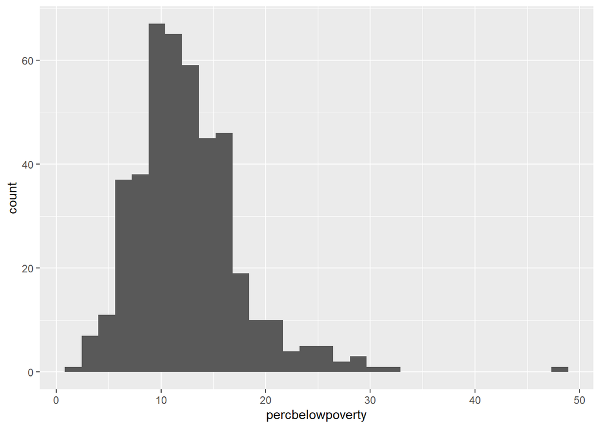

```r
ggplot(data = midwest, aes(x = percbelowpoverty)) +
  geom_histogram()
```

How many counties have poverty rates over 40 percent? What is the modal poverty rate?

To visualize relationships between variables, you can make a scatter plot. Do poverty rates appear positively or negatively correlated with race, as measured by the variable `percblack`?

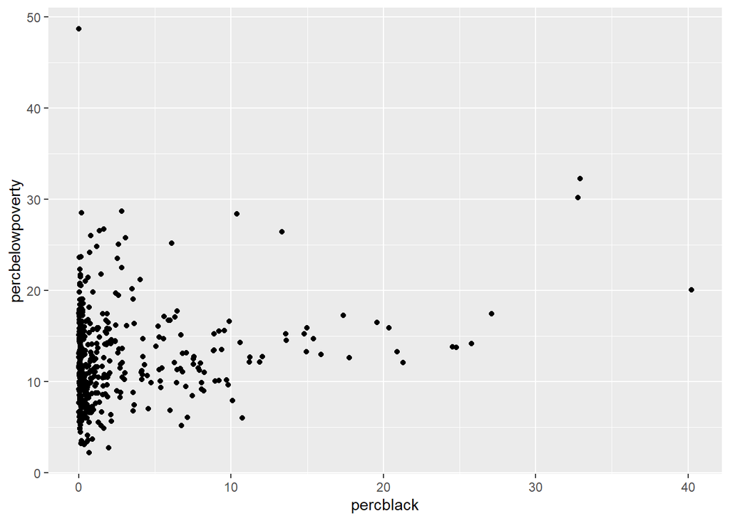

```r
ggplot(data = midwest, aes(x = percblack, y = percbelowpoverty)) +
  geom_point()
```